# Analyse de graphes multiplexes avec multinet

## Visualiser

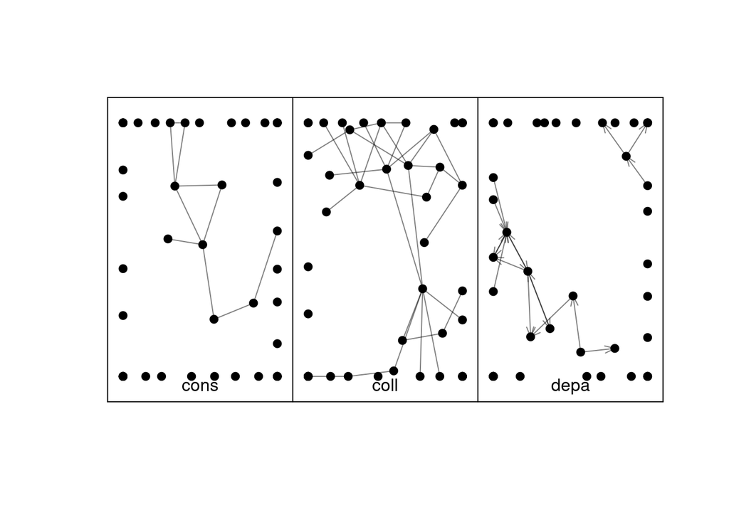

```r
#choix visualisation - layout_circular_ml
l <- layout_multiforce_ml(net)  #par défaut
plot(net, layout = l, vertex.labels = NA)
```

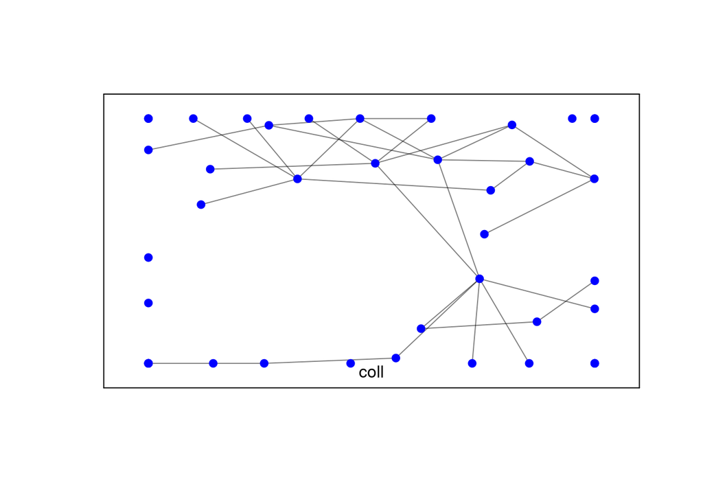

```r
#représenter une seule couche
plot(net, layout = l, layers = "coll",
     vertex.color = "blue",
     vertex.labels = NA)
```

```r
#et pour représenter le _flat_ ?
```

## Détection de communautés

```r
#détection communauté - 4 algo implémentés
#clique percolation, ABACUS, Infomap
com1 <- glouvain_ml(net)
com2 <- clique_percolation_ml(net)
#com3 <- abacus_ml(net, min.actors = 3, min.layers = 3) #error
com4 <- infomap_ml(net)

#crée dataframe : sommet, couche, communauté
head(com1, 4)
```

```
##   actor layer cid
## 1     7  cons   0
## 2     7  coll   0
## 3     7  depa   0
## 4     6  cons   0
```

```r
#nb communautés et taille selon lalgo choisi
table(com1$cid)
```

```
##
##  0  1  2  3  4  5  6  7  8  9 10 11 12 13 14
## 27  3 15  3 12  3  3 18  3  3  3  3  3  3 24
```

```r
table(com2$cid)
```

```
##
## 0 1 2 3
## 3 3 3 3
```

```r
table(com4$cid)
```

[output not shown]

```r
#indicateurs
modularity_ml(net, com1, gamma = 1, omega = 1)
```

```
## [1] 0.85
```

```r
#comparaison entre deux partitions 1 - 4
nmi_ml(net, com1, com4)
```

```
## [1] 0.947
```

```r
omega_index_ml(net, com1, com4)
```

```
## [1] 0.915
```

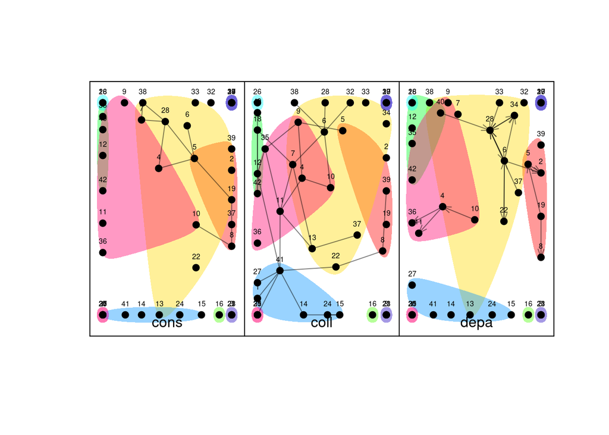

```r
#group all nodes having same comm id and same layer
#get_community_list_ml(com1, net)

#visu
plot(net, vertex.labels.cex=.5, com=com4)
```

## Questions non encore résolues

importation des attributs

tester avec une couche valuée cf si import de l’intensité des liens

```r
#importer attribut des sommets
# type <- node$TYPE
# add_attributes_ml(net,target="actor",type="numeric",
#                   attributes="type")

#couleurs
pal <- brewer.pal(n = 9, name = "Paired")

#création attributs
# degree <- degree_ml(net, actors_ml(net), layers_ml(net), mode="all")
# add_attributes_ml(net,target="actor",type="numeric",
#                   attributes="degree")
#
# plot(net, layout = l,
#      vertex.labels = type,
#      vertex.cex = log(deg), #n'est juste que sur le flat graph
#      vertex.color = pal)    #tout est faux ici ;)

#possibilité d'analyser le flat graph dans igraph
layers <- as.list(net)
names(layers)
```

```
## [1] "_flat_" "coll"   "cons"   "depa"
```

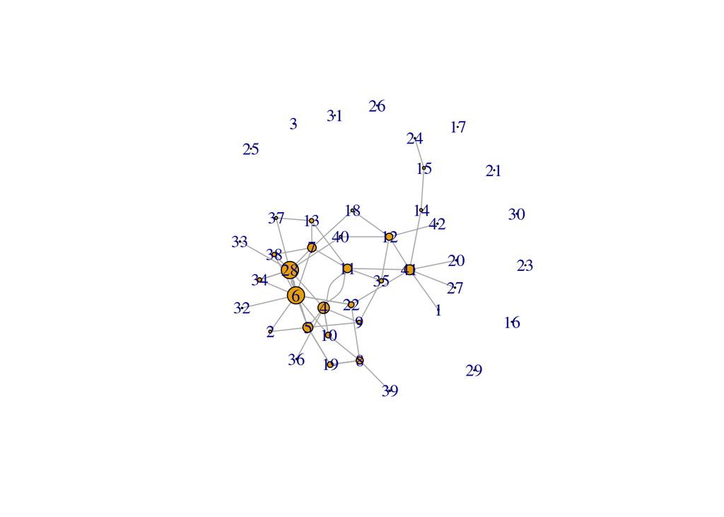

```r
plot.igraph(layers[[1]], vertex.labels = NA,
     vertex.size = degree(layers[[1]]),
     edge.arrow.size = 0)
```

## Références

Dickison, Mark E., Matteo Magnani et Luca Rossi. *Multilayer social networks*. Cambridge University Press, 2016.

Magnani, Matteo, Luca Rossi et Davide Vega. [Analysis of Multiplex Social Networks with R](http://multilayer.it.uu.se/jss.pdf). *Journal of Statistical Software*.

[Documentation du package](https://cran.r-project.org/web/packages/multinet/multinet.pdf)

Vallier, Estelle. [Voyage en cluster](https://hal.archives-ouvertes.fr/hal-01743633/document). *ARCS-Analyse de réseaux pour les sciences sociales* (2018).